# Identification of Gene Signature of Breast Cancer Subtypes Resistant to CDK4/6 Inhibitors

Daehwan Kim and Prasanna Alluri

13 February, 2018

# Outline

Steps involved in discovery of new drugs that reverse CDK4/6 inhibitor resistance:

1. Develop CDK4/6 inhibitor resistance signature
2. Screen published databases to identify drugs that reverse the signature identified in step 1 (identical to Nature Communications paper we discussed)
3. Validate findings from step 2 in the lab

# Initialization

Initialize R session by deleting existing R objects.

```r
rm(list = ls())
```

Load R libraries needed to anlayze microarray data and visualize results.

```r
library(affy)
library(affyPLM)
library(GEOquery)
library(genefilter)
library(cluster)
library(randomForest)
# library(WGCNA)
```

Define utility functions.

```r
printf <- function(...) print(sprintf(...))
```

Load gene expression data (microarray) under GSE12790, which is already included in the Git repository (https://github.com/infphilo/cowork_pa).

```r
geo_fname <- "GSE12790_series_matrix.txt.gz"
remote_fname <- paste("ftp://ftp.ncbi.nlm.nih.gov/geo/series/GSE12nnn/GSE12790/matrix/", geo_fname, sep="")
if(!file.exists(geo_fname)) download.file(remotefile, geo_fname)
hoeflich_2009 <- getGEO(filename=geo_fname)
```

Change the names of cell subtypes so that they match those of Finn et al. 2009

```r
pd <- pData(hoeflich_2009) # phenotype data
pd$cellLine <- gsub("MCF10a_Null_Vector_rep1", "MCF-10A", pd$title)
pd$cellLine <- gsub(".*_", "", pd$cellLine)
name_change <- c("MDA-MB-175VII", "MDA-MB-175",
                 "ZR75-30", "ZR-75-30",
                 "MDA-MB-134VI", "MDA-MB-134",
                 "HCC202", "HCC-202",
                 "EFM19", "EFM-19",
                 "HCC1500", "HCC-1500",
                 "HCC1419", "HCC-1419",
                 "HCC38", "HCC-38",
                 "HCC2218", "HCC-2218",
                 "ZR75-1", "ZR-75-1",
                 "T47D", "T47-D",
                 "MCF7", "MCF-7",
                 "BT20", "BT-20",
                 "MDA-MB-435s", "MDA-MB-435",
                 "BT474", "BT-474",
                 "SKBR3", "SK-BR-3",
                 "KPL1", "KPL-1",
                 "HCC1143", "HCC-1143",
                 "HCC1395", "HCC-1395",
                 "Hs578T", "Hs578t",
                 "HCC1569", "HCC-1569",
                 "HCC1937", "HCC-1937",
                 "HCC1954", "HCC-1954",
                 "HCC70", "HCC-70")
for(i in 1:(length(name_change)/2)) {
  pd$cellLine <- gsub(name_change[i*2-1], name_change[i*2], pd$cellLine)
}
hoeflich_2009$cellLine <- pd$cellLine
```

Load a list of samples analyzed in Finn et al. 2009,

```r
finn_2009 <- read.table("Finn_2009.txt", header = TRUE, sep = "\t")
```

in which there are 47 subtypes. Unfortunately, their gene expression data is not publically available.

Identify and use the cell lines available from Hoeflich et al. 2009 that match Finn et al. 2009.

```r
selected_cols <- which(pd$cellLine %in% finn_2009$cellLine)
hoeflich_2009 <- hoeflich_2009[,selected_cols]
```

There are 38 subtypes common to both Hoeflich et al. 2009 and Finn et al. 2009, which we will use in our analysis of identifying gene signature resistant to CDK4/6 inhibitor (e.g. PD 0332991).

The following box plot shows the distribution of expression values across those 38 subtypes.

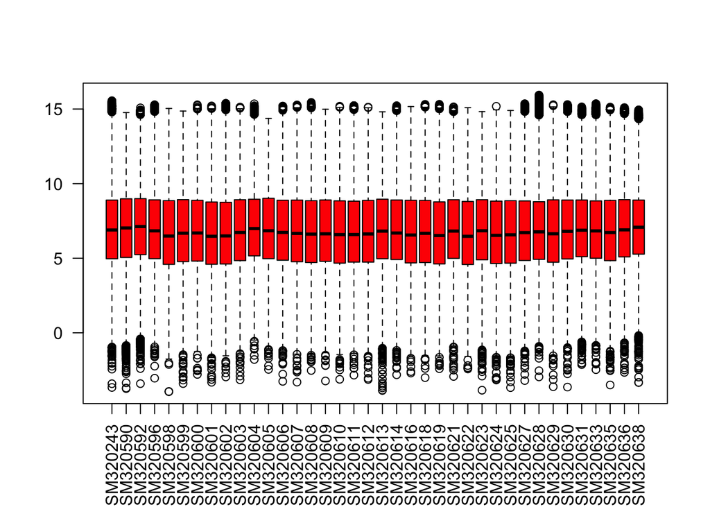

```r
boxplot(log2(exprs(hoeflich_2009)), col="red", las=2)
```

The following MVA plot shows M (log ratio) as Y axis and A (mean average) as X axis of a pair of gene expression values (a, b) for each pair of four samples. A is defined as (log(a) + log(b)) / 2 and M is defined as log(a) - log(b).

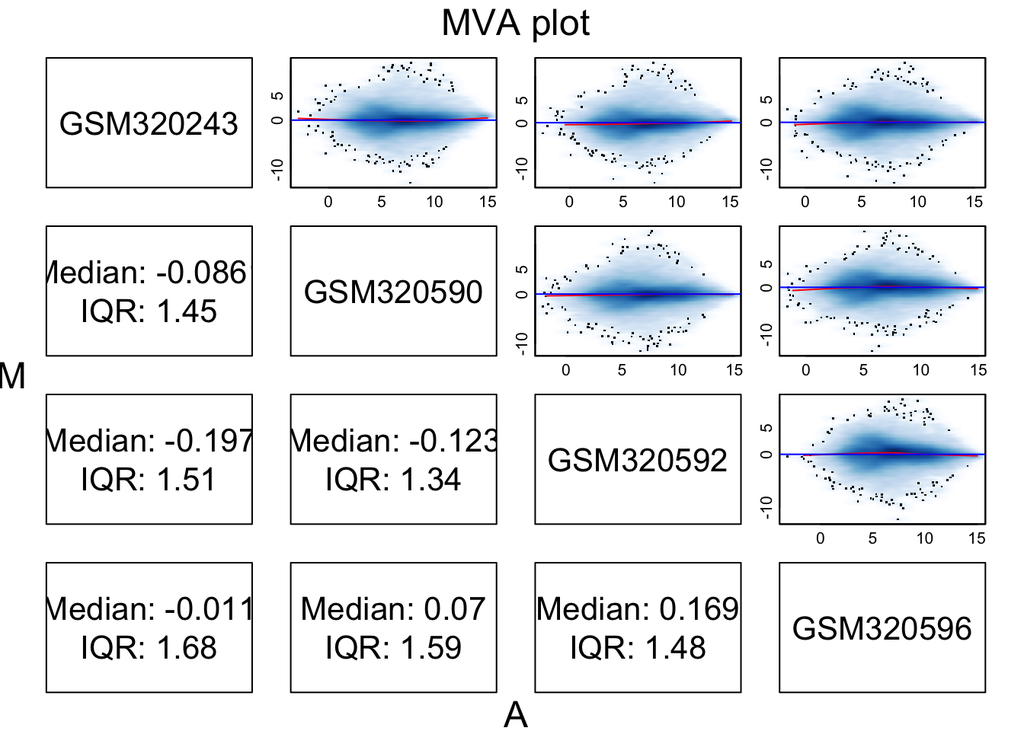

```r
mva.pairs(exprs(hoeflich_2009)[,1:4], plot.method="smoothScatter")
```

```r
# Show images of gene expression values - it doesn't work now.
if(FALSE) {
ncol <- (ncol(hoeflich_2009) + 3) / 4
par(mfrow=c(4,ncol))
for(i in 1:ncol(hoeflich_2009)) {
  image(log2(exprs(hoeflich_2009[,i])))
}
}
```

Combine loci into groups that correspond to genes.

```r
h2009_exprs <- as.data.frame(exprs(hoeflich_2009))
locus2gene <- fData(hoeflich_2009)[c("ID", "Gene Symbol")]
stopifnot(rownames(h2009_exprs) == locus2gene$ID)
geneSymbol <- locus2gene$`Gene Symbol`
h2009_exprs <- cbind(geneSymbol, h2009_exprs)
```

Show gene expression values of four samples at WFDC2 and MAPK1.

```r
with(h2009_exprs, {
  h2009_exprs[geneSymbol == 'WFDC2' | geneSymbol == 'MAPK1', 1:5]
})
```

```
##              geneSymbol GSM320243  GSM320590  GSM320592   GSM320596
## 1552261_at        WFDC2    58.546   51.44777   23.63561    7.829851
## 1552263_at        MAPK1   481.278  449.47660  249.45170   85.032500
## 1552264_a_at      MAPK1   660.067  683.46380  702.34700 1222.423000
## 1553089_a_at      WFDC2    11.965   13.98372   23.71795   24.467510
## 203892_at         WFDC2   631.863  227.85380  269.07880  196.356000
## 208351_s_at       MAPK1   913.922  467.39560  727.88290 1182.547000
## 212271_at         MAPK1  2472.879 2471.94800 2560.11500 3434.747000
## 224620_at         MAPK1    14.418   36.73162   19.08121   17.831600
## 224621_at         MAPK1  3525.453 3134.78300 3818.44400 3218.701000
## 229847_at         MAPK1    95.637  117.45940   88.00325   88.969590
```

Merge gene expression values that belong to the same gene by the mean of the values.

```r
h2009_exprs <- aggregate(h2009_exprs[,2:ncol(h2009_exprs)], by = list(geneSymbol), FUN = mean)
rownames(h2009_exprs) <- h2009_exprs[,1]
h2009_exprs <- h2009_exprs[,-1]
```

```r
h2009_exprs[c("WFDC2", "MAPK1"), 1:4]
```

```
##       GSM320243  GSM320590 GSM320592  GSM320596
## WFDC2  234.1247   97.76176  105.4775   76.21779
## MAPK1 1166.2363 1051.60829 1166.4750 1321.46453
```

```r
h2009_exprs <- log2(h2009_exprs)
```

For example, the log transformed gene expression values at **MAPK1** are as follows:

```
##       GSM320243 GSM320590 GSM320592 GSM320596
## MAPK1  10.18764  10.03838  10.18794  10.36792
```

Add GEO ID to Finn et al. 2009 data.

```r
h2009_pd <- pData(hoeflich_2009)
finn_2009 <- merge(finn_2009, h2009_pd[, c("geo_accession", "cellLine")])
```

Finn et al. 2009’s data used in the analysis:

```
##      cellLine IC50 breastCancerSubtype ERStatus   HER2Status geo_accession
## 25 MDA-MB-175    4             Luminal Positive       Normal     GSM320603
## 38   ZR-75-30    5             Luminal Positive    Amplified     GSM320633
## 5      CAMA-1    8             Luminal Positive       Normal     GSM320599
## 24 MDA-MB-134   13             Luminal Positive       Normal     GSM320592
## 16    HCC-202   21             Luminal Positive    Amplified     GSM320623
## 36   UACC-893   24             Luminal Positive    Amplified     GSM320638
## 7      EFM-19   27             Luminal Positive       Normal     GSM320618
## 8    EFM-192A   42             Luminal Positive    Amplified     GSM320619
## 27 MDA-MB-361   44             Luminal Positive    Amplified     GSM320605
## 12   HCC-1500   45             Luminal Positive       Normal     GSM320629
## 11   HCC-1419   51             Luminal Positive    Amplified     GSM320624
## 18     HCC-38   64               Basal Negative       Normal     GSM320636
## 28 MDA-MB-415   64             Luminal Positive       Normal     GSM320606
## 22    MCF-10A   92                 n/a Negative Immortalized     GSM320243
```

[output cut: 24 more lines]

Identify genes that are differentially expressed either positively or negatively across 38 breast cancer subtypes.

```r
gene_names <- rownames(h2009_exprs)

stopifnot(finn_2009$geo_accession == colnames(h2009_exprs))
IC50 <- finn_2009$IC50
logIC50 <- log(IC50)
cor_table <- data.frame(matrix(nrow=nrow(h2009_exprs), ncol=2))
colnames(cor_table) <- c("locus", "cor")

cor_table[,1] <- gene_names
cor_table[,2] <- apply(h2009_exprs, 1, function(x) cor(x, logIC50, method="pearson"))
cor_order <- order(cor_table$cor)
```

Histogram of correlation values between IC50 and gene expression.

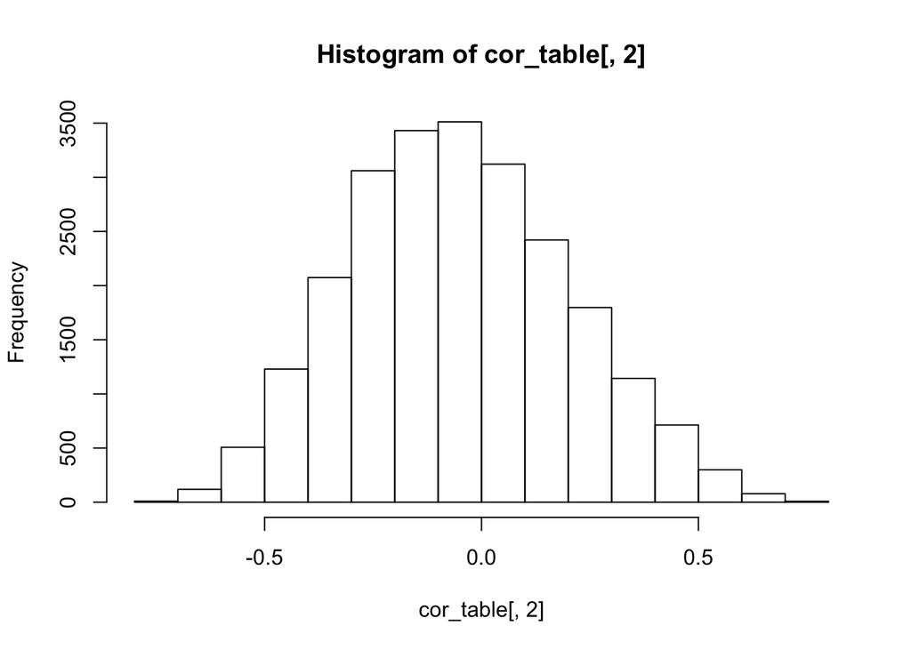

```r
hist(cor_table[,2])
```

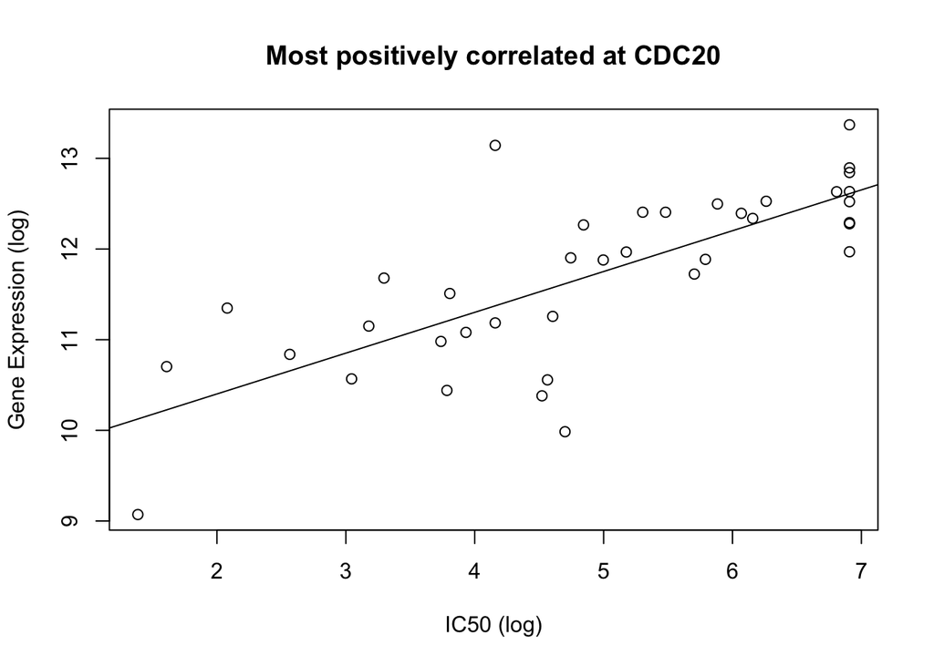

```r
gene_names <- rownames(h2009_exprs)
most_pos_i <- cor_order[length(cor_order)]
plot(x=logIC50, y=h2009_exprs[most_pos_i,], xlab="IC50 (log)", ylab="Gene Expression (log)", main=paste("Most positively correlated at",gene_names[most_pos_i]))
abline(lm(t(h2009_exprs[most_pos_i,]) ~ logIC50))
```

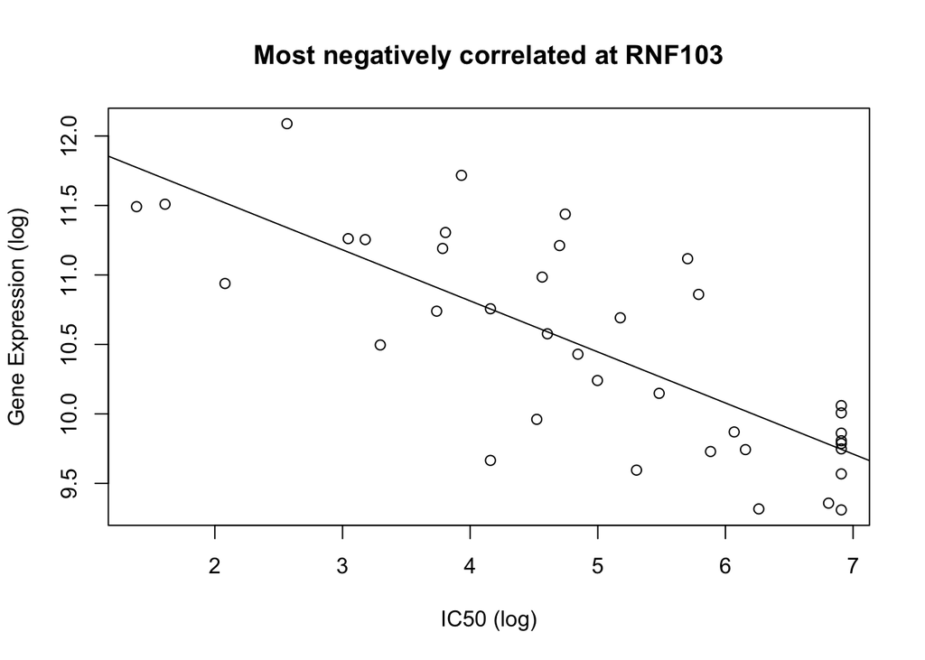

```r
most_neg_i <- cor_order[1]
plot(x=logIC50, y=h2009_exprs[most_neg_i,], xlab="IC50 (log)", ylab="Gene Expression (log)", main=paste("Most negatively correlated at",gene_names[most_neg_i]))
abline(lm(t(h2009_exprs[most_neg_i,]) ~ logIC50))
```

Show a heapmap.

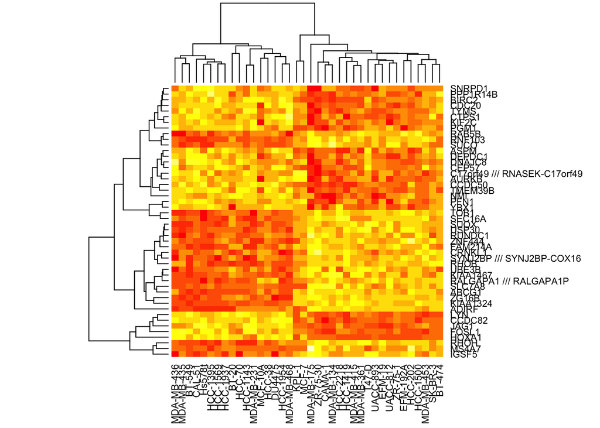

```r
pos_th <- quantile(cor_table$cor, 0.999)
neg_th <- quantile(cor_table$cor, 0.001)

pos_rows <- which(cor_table$cor >= pos_th)
neg_rows <- which(cor_table$cor <= neg_th)
diff_rows <- c(pos_rows, neg_rows)

# Differentially expressed genes
diff_exprs <- as.matrix(h2009_exprs[diff_rows,])
colnames(diff_exprs) <- finn_2009$cellLine
heatmap(diff_exprs)
```

```r
finn_2009[order(finn_2009$IC50), "cellLine"]
```

```
##  [1] MDA-MB-175 ZR-75-30   CAMA-1     MDA-MB-134 HCC-202    UACC-893
##  [7] EFM-19     EFM-192A   MDA-MB-361 HCC-1500   HCC-1419   MDA-MB-415
## [13] HCC-38     MCF-10A    UACC-812   HCC-2218   ZR-75-1    MDA-MB-453
## [19] T47-D      MCF-7      BT-20      MDA-MB-435 BT-474     SK-BR-3
## [25] KPL-1      HCC-1143   MDA-MB-231 HCC-1395   Hs578t     CAL-51
## [31] BT-549     DU4475     MDA-MB-436 MDA-MB-468 HCC-1937   HCC-70
## [37] HCC-1954   HCC-1569
## 47 Levels: 184A1 184B5 BT-20 BT-474 BT-549 CAL-51 CAMA-1 ... ZR-75-30
```

Create resistance signature (R-Sig) to mimic M-Sig developed in Zhao et al. 2015 using a random forest of 1,000 trees.

```r
samples <- t(diff_exprs)
stopifnot(rownames(samples) == finn_2009$cellLine)
samples <- cbind(samples, finn_2009$IC50)
colnames(samples)[ncol(samples)] <- "IC50"
colnames(samples) <- gsub(" ///.*", "", colnames(samples))
train <- sample(1:nrow(samples), nrow(samples) - 5)
rsig <- randomForest(IC50 ~ ., data = samples, subset = train, ntree = 1000)
print(rsig)
```

```
##
## Call:
##  randomForest(formula = IC50 ~ ., data = samples, ntree = 1000,      subset = train)
##                Type of random forest: regression
##                      Number of trees: 1000
## No. of variables tried at each split: 16
##
##           Mean of squared residuals: 54003.37
##                     % Var explained: 62.57
```

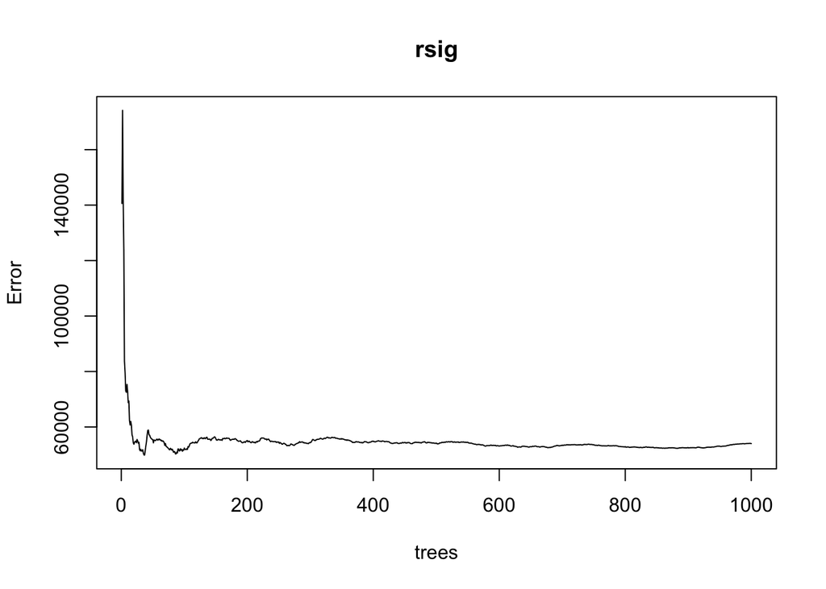

```r
plot(rsig)
```

```r
# print(importance(rsig, type = 2))
print("True IC50 values:")
```

```
## [1] "True IC50 values:"
```

```r
samples[-train,"IC50"]
```

```
##     DU4475 MDA-MB-175      T47-D   UACC-812   UACC-893
##       1000          4        127         96         24
```

```r
print("Predicted IC50 values:")
```

```
## [1] "Predicted IC50 values:"
```

```r
predict(rsig, samples[-train,])
```

```
##     DU4475 MDA-MB-175      T47-D   UACC-812   UACC-893
##  490.33112   46.47402  154.38990   75.15672   99.67843
```

# Supplementary Materials

A comprehensive tutorial for analysis of microarray data is available at http://bioinformatics-core-shared-training.github.io/microarray-analysis/ A tutorial for random forest is available at https://www.r-bloggers.com/random-forests-in-r/

Additional codes:

```r
# raw <- varFilter(raw)

# features[grep("TP53", features$`Gene Symbol`),]
# features[which(features$`Gene Symbol` == "TP53"),]
# features[match("TP53", features$`Gene Symbol`),]
# which(features$`Gene Symbol` == "TP53")

# Calcuate Euclidean distances among samples
euc.dist <- dist(t(exprs(raw)))

# corMat <-cor(exprs(raw))
# cor.dist <- as.dist(1 - corMat)

clust <- hclust(euc.dist)
clust
par(mfrow=c(1,1))

sample_group <- pd$characteristics_ch1
group_colors <- sample_group
levels(group_colors) <- c("yellow","blue", "red", "green", "gray", "black", "orange", "ivory")

clust.euclid <- plot(clust, labels=pd$title, cex=0.5)
# plotDendroAndColors(clust.euclid, colors=group_colors)

# Examples

targetsFile <- "estrogen/estrogen.txt"
pd <- read.AnnotatedDataFrame(targetsFile, header=TRUE, sep="", row.names=1)
raw <-ReadAffy(celfile.path="estrogen", filenames=rownames(pData(pd)), phenoData = pd)
boxplot(raw, col="red", las=2)

par(mfrow=c(2,1))
hist(log2(pm(raw[,1])), breaks=100, col="steelblue", main="PM", xlim=c(4,14))
hist(log2(mm(raw[,1])), breaks=100, col="steelblue", main="MM", xlim=c(4,14))

mva.pairs(pm(raw)[,1:4], plot.method="smoothScatter")

plmset <- fitPLM(raw)
NUSE(plmset,las=2)
RLE(plmset,las=2)

par(mfrow=c(2,4))
image(raw[,1])
image(raw[,2])
image(raw[,3])
image(raw[,4])
image(raw[,5])
image(raw[,6])
image(raw[,7])
image(raw[,8])

eset <- rma(raw)
head(exprs(eset))
summary(exprs(eset))
boxplot(exprs(eset),las=2)
mva.pairs(exprs(eset)[,1:4],log.it = FALSE,plot.method="smoothScatter")
```